# EDA - CEAP - Parte 2

## Os Dados

```r
data %>% glimpse()
```

```
## Observations: 963,452
## Variables: 14
## $ nomeParlamentar <chr> "ABEL MESQUITA JR.", "ABEL MESQUITA JR.", "ABE...
## $ idCadastro      <int> 178957, 178957, 178957, 178957, 178957, 178957...
## $ sgUF            <chr> "RR", "RR", "RR", "RR", "RR", "RR", "RR", "RR"...
## $ sgPartido       <chr> "DEM", "DEM", "DEM", "DEM", "DEM", "DEM", "DEM...
## $ tipoDespesa     <chr> "MANUTENÇÃO DE ESCRITÓRIO DE APOIO À ATIVIDADE...
## $ especDespesa    <chr> NA, NA, NA, NA, NA, "Veículos Automotores", "V...
## $ fornecedor      <chr> "COMPANHIA DE AGUAS E ESGOTOS DE RORAIMA", "CO...
## $ CNPJCPF         <chr> "05939467000115", "05939467000115", "023414700...
## $ tipoDocumento   <int> 0, 0, 0, 0, 0, 0, 0, 0, 0, 0, 0, 0, 0, 0, 0, 0...
## $ dataEmissao     <chr> "2015-11-14 00:00:00", "2015-12-10 00:00:00", ...
## $ valorDocumento  <dbl> 165.65, 59.48, 130.95, 196.53, 310.25, 32.00, ...
## $ valorGlosa      <int> 0, 0, 0, 347, 0, 0, 0, 0, 0, 0, 0, 0, 0, 0, 0,...
## $ valorLíquido    <dbl> 165.65, 59.48, 130.95, 193.06, 310.25, 32.00, ...
## $ limiteMensal    <dbl> 45612.53, 45612.53, 45612.53, 45612.53, 45612....
```

Para a nossa análise iremos utilizar dados sobre as despesas dos deputados federais da legislatura atual com a atividade parlamentar. Para isso usaremos os dados do CEAP, que é uma cota única mensal destinada a custear os gastos dos deputados exclusivamente vinculados ao exercício da atividade parlamentar.

Os dados foram coletados no site de transparência da Câmara.

### Descrição das variáveis

No nosso conjunto de dados nós temos 14 variáveis:

#### nomeParlamentar

```
Nome adotado pelo Parlamentar ao tomar posse do seu mandato.
```

#### idCadastro

```
Número que identifica unicamente um deputado federal na CD.
```

#### sgUF

```
No contexto da cota CEAP, representa a unidade da federação pela qual o deputado foi eleito e é utilizada para definir o valor da cota a que o deputado tem.
```

#### sgPartido

```
Sigla do partido do parlamentar.
```

#### tipoDespesa

```
O seu conteúdo é a descrição do Tipo de Despesa relativo à despesa em questão.
```

#### especDespesa

```
Representa a descrição  especificação mais detalhada de um referido Tipo de Despesa.
```

#### fornecedor

```
O conteúdo deste dado representa o nome do fornecedor do produto ou serviço presente no documento fiscal
```

#### CNPJCPF

```
O conteúdo deste dado representa o CNPJ ou o CPF do emitente do documento fiscal, quando se tratar do uso da cota em razão do reembolso despesas comprovadas pela emissão de documentos fiscais.
```

#### tipoDocumento

```
Este dado representa o tipo de documento do fiscal – 0 (Zero), para Nota Fiscal; 1 (um), para Recibo; e 2, para Despesa no Exterior.
```

#### dataEmissao

```
O conteúdo deste dado é a data de emissão do documento fiscal ou a data do documento que tenha dado causa à despesa.
```

#### valorDocumento

[output not shown]

#### valorGlosa

```
O seu conteúdo representa o valor da glosa do documento fiscal que incidirá sobre o Valor do Documento, ou o valor da glosa do documento que deu causa à despesa.
```

#### valorLiquido

[output not shown]

#### limiteMensal

```
O seu conteúdo representa o límite mensal de CEAP para o estado (UF) do parlamentar.
```

# Como se comportam as despesas com combustíveis por Estado?

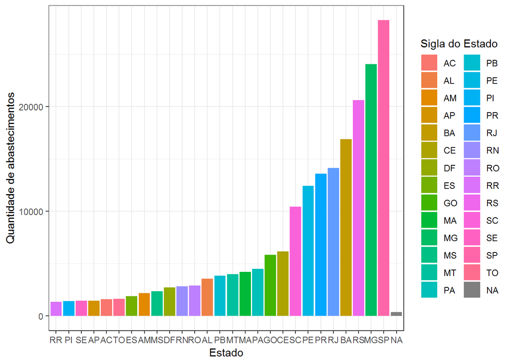

```r
data %>%
  filter(tipoDespesa %in% c("COMBUSTÍVEIS E LUBRIFICANTES.")) %>%
  group_by(sgUF,
           tipoDespesa) %>%
  summarize(n = n()) %>%
  ggplot(aes(x = reorder(sgUF, n),
             y = n,
             fill = sgUF)) +
  geom_bar(stat = "identity") +
  labs(x = "Estado",
       y = "Quantidade de abastecimentos",
       fill = "Sigla do Estado")
```

Com a visualização acima conseguimos perceber que dentre os estados que mais abastecem temos **SP (São Paulo)** e **MG (Minas Gerais)**.

### Abasteceu o que tanto?

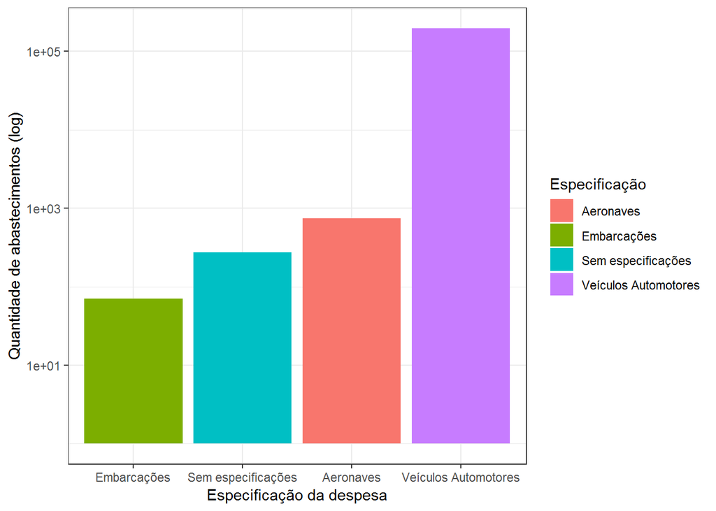

```r
data %>%
  filter(tipoDespesa %in% c("COMBUSTÍVEIS E LUBRIFICANTES.")) %>%
  group_by(especDespesa) %>%
  summarize(n = n()) %>%
  ggplot(aes(x = reorder(especDespesa, n),
             y = n,
             fill = especDespesa)) +
  geom_bar(stat = "identity") +
  scale_y_log10() +
  labs(x = "Especificação da despesa",
       y = "Quantidade de abastecimentos (log)",
       fill = "Especificação")
```

Com a visualização acima podemos ver que temos quatro especificações diferentes para despesas do tipo `COMBUSTÍVEIS E LUBRIFICANTES`:

### Embarcações

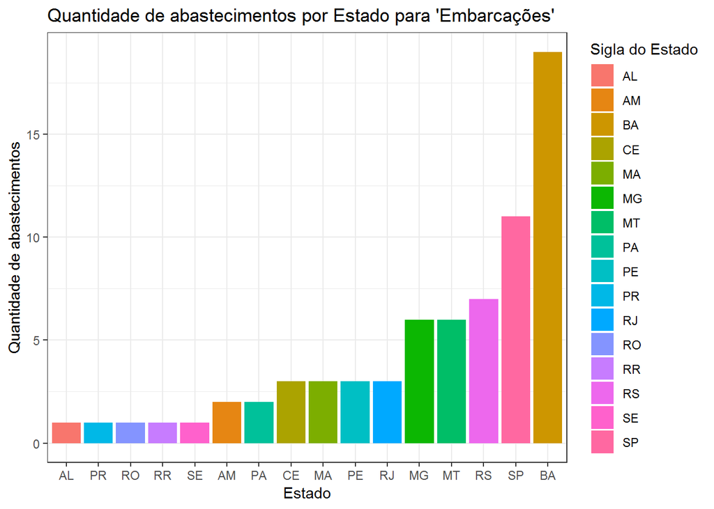

```r
data %>%
  filter(tipoDespesa %in% c("COMBUSTÍVEIS E LUBRIFICANTES.")) %>%
  group_by(sgUF,
           especDespesa) %>%
  summarize(n = n()) %>%
  filter(especDespesa %in% c("Embarcações")) %>%
  ggplot(aes(x = reorder(sgUF, n),
             y = n,
             fill = sgUF)) +
  geom_bar(stat = "identity") +
  labs(title = "Quantidade de abastecimentos por Estado para 'Embarcações'",
       x = "Estado",
       y = "Quantidade de abastecimentos",
       fill = "Sigla do Estado")
```

Para **Embarcações** temos que o estado da **BA (Bahia)** é o vencedor no quesito *“quantidade de abastecimentos”*, a única coisa que vem na minha cabeça para talvez justificar esse uso ao visualizar essa diferença é a questão dos portos/docas, mas o motivo para usarem o dinheiro do **CEAP** para isso aí já não posso dizer muita coisa.

### Sem especificações

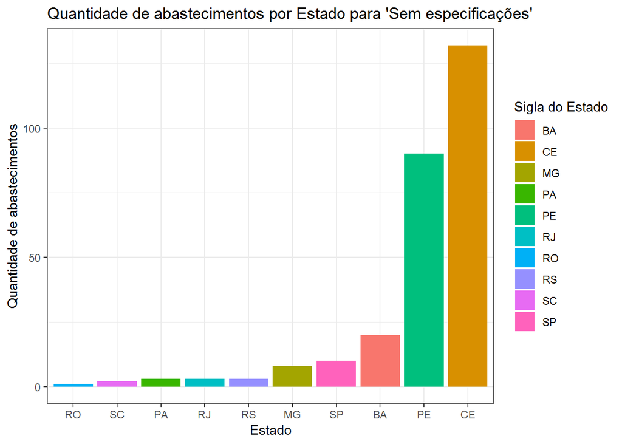

```r
data %>%
  filter(tipoDespesa %in% c("COMBUSTÍVEIS E LUBRIFICANTES.")) %>%
  group_by(sgUF,
           especDespesa) %>%
  summarize(n = n()) %>%
  filter(especDespesa %in% c("Sem especificações")) %>%
  ggplot(aes(x = reorder(sgUF, n),
             y = n,
             fill = sgUF)) +
  geom_bar(stat = "identity") +
  labs(title = "Quantidade de abastecimentos por Estado para 'Sem especificações'",
       x = "Estado",
       y = "Quantidade de abastecimentos",
       fill = "Sigla do Estado")
```

Nessa visualização temos que o **CE (Ceará)** possui mais gastos “Sem especificação” quando se trata do tipo `COMBUSTÍVEIS E LUBRIFICANTES`, não temos muitas conclusões a cerca disso pois não sabemos os motivos pelos quais não houve espeficicação, mas é algo para se investigar.

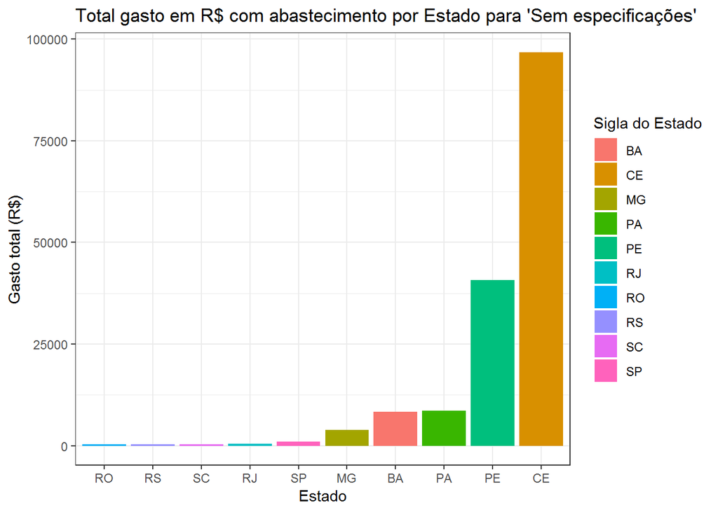

```r
data %>%
  filter(tipoDespesa %in% c("COMBUSTÍVEIS E LUBRIFICANTES.")) %>%
  group_by(sgUF,
           especDespesa) %>%
  summarize(somaGastos = sum(valorLíquido)) %>%
  filter(especDespesa %in% c("Sem especificações")) %>%
  ggplot(aes(x = reorder(sgUF, somaGastos),
             y = somaGastos,
             fill = sgUF)) +
  geom_bar(stat = "identity") +
  labs(title = "Total gasto em R$ com abastecimento por Estado para 'Sem especificações'",
       x = "Estado",
       y = "Gasto total (R$)",
       fill = "Sigla do Estado")
```

### Aeronaves

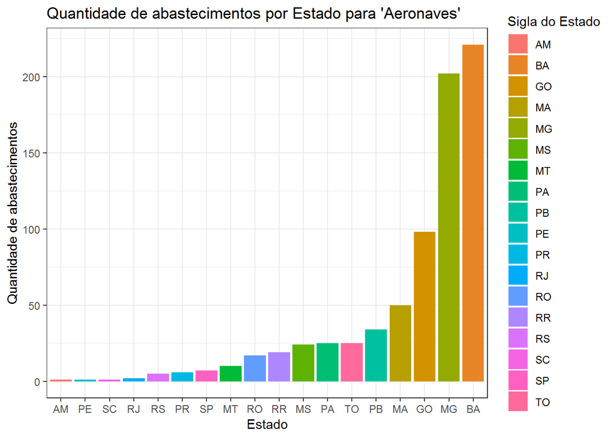

```r
data %>%
  filter(tipoDespesa %in% c("COMBUSTÍVEIS E LUBRIFICANTES.")) %>%
  group_by(sgUF,
           especDespesa) %>%
  summarize(n = n()) %>%
  filter(especDespesa %in% c("Aeronaves")) %>%
  ggplot(aes(x = reorder(sgUF, n),
             y = n,
             fill = sgUF)) +
  geom_bar(stat = "identity") +
  labs(title = "Quantidade de abastecimentos por Estado para 'Aeronaves'",
       x = "Estado",
       y = "Quantidade de abastecimentos",
       fill = "Sigla do Estado")
```

Novamente a **BA (Bahia)** está no topo, pelo visto os parlamentares da Bahia costumam viajar pelo *ar* e pela *água* `¯\_(ツ)_/¯`

### Veículos Automotores

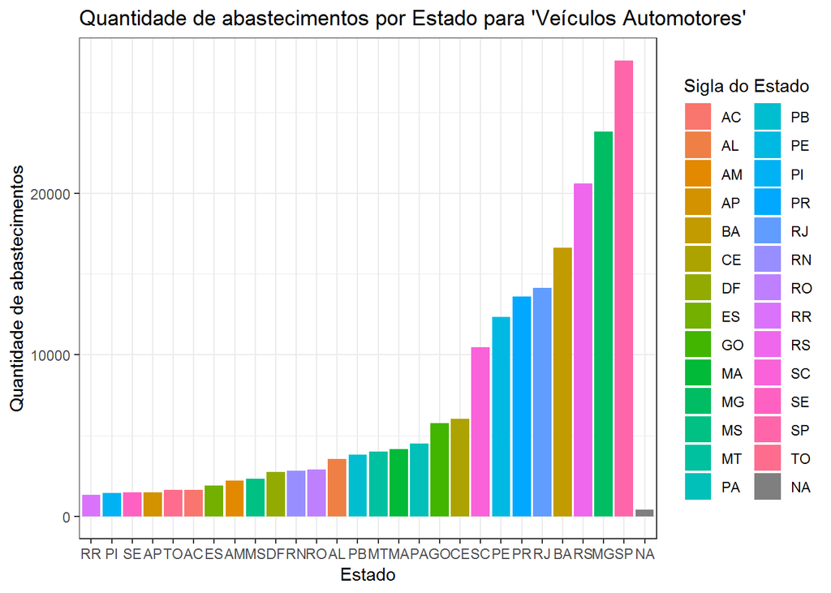

```r
data %>%
  filter(tipoDespesa %in% c("COMBUSTÍVEIS E LUBRIFICANTES.")) %>%
  group_by(sgUF,
           especDespesa) %>%
  summarize(n = n()) %>%
  filter(especDespesa %in% c("Veículos Automotores")) %>%
  ggplot(aes(x = reorder(sgUF, n),
             y = n,
             fill = sgUF)) +
  geom_bar(stat = "identity") +
  labs(title = "Quantidade de abastecimentos por Estado para 'Veículos Automotores'",
       x = "Estado",
       y = "Quantidade de abastecimentos",
       fill = "Sigla do Estado")
```

Com uma visualização semelhante a que vimos mais acima, **SP (São Paulo)** e **MG (Minas Gerais)** estão em primeiro lugar na quantidade de abastecimentos à Veículos Automotores.

É curioso também observar que a **BA (Bahia)** está entre os que mais abastecem Veículos Automotores, ou seja, além de Embarcações e Aeronaves eles também abastecem Veículos Automotores com bastante frequência…

# Quais são os postos de combustíveis que mais atendem os parlamentares?

Seria o motivo do abastecimento a confiança para com o posto ou algum tipo de “amizade” ou “relação empresarial”?

Em uma breve estudada nos dados pude perceber que existem muitos gastos com o tipo `COMBUSTÍVEIS E LUBRIFICANTES`, onde os abastecimentos foram de `Veículos Automotores` e em alguns casos temos também abastecimento de `Aeronaves`, `Embarcações` e `Sem especificações`.

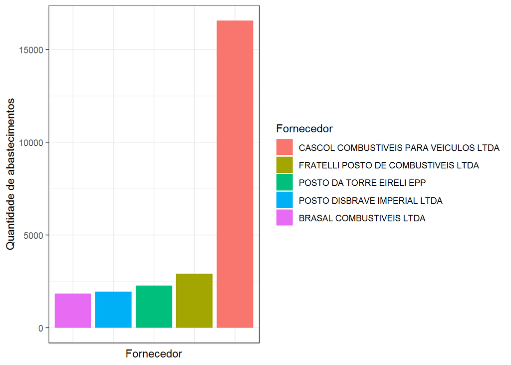

```r
data %>%
  filter(tipoDespesa %in% c("COMBUSTÍVEIS E LUBRIFICANTES.")) %>%
  mutate(fornecedor = gsub("\\.", "", toupper(stringi::stri_trans_general(fornecedor,'Latin-ASCII')))) %>% # remove os acentos, deixa tudo em uppercase e em seguida remove os pontos pois em alguns casos o fornecedor é o mesmo mas há diferença de acentuação, pontuação e tipo da escrita (maiúscula ou minúscula)
  group_by(tipoDespesa,
           fornecedor) %>%
  summarize(n = n()) %>%
  arrange(-n) %>%
  slice(c(1:5)) %>%
  ggplot(aes(x = reorder(fornecedor, n),
             y = n,
             fill = reorder(fornecedor, -n))) +
  geom_bar(stat = "identity") +
  theme(axis.text.x=element_blank(),
        axis.ticks.x=element_blank()) +
  labs(x = "Fornecedor",
       y = "Quantidade de abastecimentos",
       fill = "Fornecedor")
```

É possível pereceber que o fornecedor `CASCOL COMBUSTÍVEIS PARA VEÍCULOS LTDA` é a campeã em vendas, tendo abastecido mais de 15000 vezes os parlamentares, enquanto o `FRATELI POSTO DE COMBUSTÍVEIS LTDA`, que é o segundo colocado, não chegou nem a 5000 abastecimentos.

Dando uma breve pesquisada em `CASCOL` pude perceber que é uma rede que possui muitas unidades em **Brasília**, no **Distrito Federal**. E também não é muito difícil encontrar matérias nos jornais que mostrem *polêmicas* envolvendo essa rede de postos.

Os parlamentares que estão no *Palácio do Planalto* abastecem bastante.

## Tá bom ou quer mais?

Vamos tentar visualizar agora a quantidade em R$ que os postos conseguiram faturar com os abastecimentos realizados:

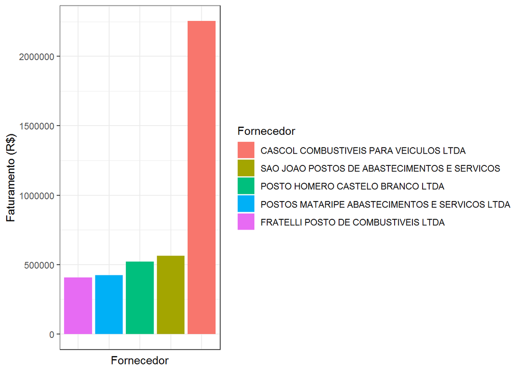

```r
data %>%
  filter(tipoDespesa %in% c("COMBUSTÍVEIS E LUBRIFICANTES.")) %>%
  mutate(fornecedor = gsub("\\.", "", toupper(stringi::stri_trans_general(fornecedor,'Latin-ASCII')))) %>% # remove os acentos, deixa tudo em uppercase e em seguida remove os pontos pois em alguns casos o fornecedor é o mesmo mas há diferença de acentuação, pontuação e tipo da escrita (maiúscula ou minúscula)
  group_by(tipoDespesa,
           fornecedor) %>%
  summarize(gastoTotal = sum(valorLíquido)) %>%
  arrange(-gastoTotal) %>%
  slice(c(1:5)) %>%
  ggplot(aes(x = reorder(fornecedor, gastoTotal),
             y = gastoTotal,
             fill = reorder(fornecedor, -gastoTotal))) +
  geom_bar(stat = "identity") +
  theme(axis.text.x=element_blank(),
        axis.ticks.x=element_blank()) +
  labs(x = "Fornecedor",
       y = "Faturamento (R$)",
       fill = "Fornecedor")
```

O posto `CASCOL COMBUSTÍVEIS PARA VEÍCULOS LTDA` novamente está em primeiro (como esperado) e faturou uma quantia simbólica de **R$ 2.253.421,89**. Isso mesmo.

Não sei se é necessário que eu escreva mais alguma coisa… `(ಥ﹏ಥ)`